# BAYESIAN REGRESSION THEORY

# Linear Regression and Basis Functions

Let us remember what is the general expression for a linear regression model using non-linear basis functions:

$$\hat{y}=w_{0} + \sum_{j=1}^{n-1}w_{j}\phi_{j}(x) = \sum_{j=0}^{n-1}w_{j}\phi_{j}(x)=w^{T}\phi(x)$$

where $\phi_{j}$ are the basis functions and $n$ is the number of parameters $w_{j}$ in the model.

From the Bayesian approach, we remember that labels are modeled by adding random noise $\epsilon$ to them:

$$y=\hat{y}+\epsilon$$

We make the assumption that the noise $\epsilon$ is normally distributed with zero mean and inverse variance $\beta$.

$$p(y/x,w,\beta)=N(y/\hat{y}(x,w),\beta^{-1})=\sqrt{\frac{\beta}{2\pi}}(exp(\frac{-\beta}{2}(y-\hat{y})^{2}))$$

# Log-Likelihood

The log likelihood could be written as:

$$log(p(y/x,w,beta))=\sum_{i=1}^{m}log(N(y^{(i)}/w^{T}x^{(i)},\beta^{-1}))$$$$log(p(y/x,w,beta))=\sum_{i=1}^{m}log(\sqrt{\frac{\beta}{2\pi}}(exp(\frac{-\beta}{2}(y-\hat{y})^{2}))$$$$log(p(y/x,w,beta))=\frac{m}{2}log(\beta)-\frac{m}{2}log(2\pi)-\beta(\frac{1}{2} (y-\phi w)^{T}(y-\phi w))$$

# Prior and posterior distributions

We model our prior distribution as an isotropic Gaussian distribution over parameters $w$ with zero mean:

$$p(w/\alpha)=N(w/0, \alpha^{-1}I)=exp(\frac{-\alpha}{2}w^{T}w)$$

An isotropic Gaussian distribution has a diagonal covariance matrix where all diagonal elements have the same variance $α^{-1}$. An important thing to note is that **the prior is conjugate to the likelihood $p(t|w,\beta)$ (belong to the Gaussian family)** .

**This means that the posterior distribution has the same functional form as the prior**.

$$p(w/y,\alpha, \beta)\propto p(y/x,w,beta) p(w/\alpha)$$$$p(w/y,\alpha, \beta)\propto [exp(\frac{-\beta}{2}(y-\phi w)^{T}(y-\phi w))] [exp(\frac{-\alpha}{2}w^{T}w))]$$$$p(w/y,\alpha, \beta)\propto [exp(\frac{-\beta}{2}(y-\phi w)^{T}(y-\phi w) - \frac{\alpha}{2}w^{T}w))] $$$$p(w/y,\alpha, \beta)\propto [exp(-\frac{1}{2}[\beta(y-\phi w)^{T}(y-\phi w) + \alpha w^{T}w]))] $$$$p(w/y,\alpha, \beta)\propto [exp(-\frac{1}{2}[\beta[y^{T}y-2w^{T}\phi^{T}y + w^{T}\phi^{T}\phi w] + \alpha w^{T}w]))] $$$$p(w/y,\alpha, \beta)\propto [exp(-\frac{1}{2}[\beta[y^{T}y]-\beta[2w^{T}\phi^{T}y] + w^{T}[\beta \phi^{T}\phi +\alpha I]w]) $$

Let us remember that the general form of the exponent in a Gaussian is $(w-\mu)^{T}S(w-\mu)$ where $\mu$ is the mean vector and $S$ is the precision matrix (the inverse of the variance).

Thus, expanding we have $(w-\mu)^{T}S(w-\mu)=w^{T}Sw-2w^{T}S\mu + \mu^{T} S \mu$. Therefore, in our case we will have:

$$S=\beta \phi^{T}\phi +\alpha I$$

To match the equation we will have:

$$\beta[y^{T}y]-2\beta[w^{T}\phi^{T}y] + w^{T}[\beta \phi^{T}\phi +\alpha I]w$$$$\beta[y^{T}y]-2\beta[w^{T}\phi^{T}y] + w^{T}Sw$$

Thus we need to get the final expression:

$$ \beta w^{T}\phi^{T}y = w^{T}S\mu$$$$ \beta\phi^{T}y = S\mu$$

Because we impose an isotropic Gaussin distribution to our prior, we know that $S$ is invertible:

$$ \mu = \beta S^{-1} \phi^{T}y $$$$ S =\alpha I + \beta \phi^{T}\phi $$

**The posterior distribution will be:**

$$ p(w/y, \alpha, \beta) = N(w/m_{N}, S_{N}) $$

$$ m_{N} = \beta S_{N}^{-1} \phi^{T}y $$$$ S_{N} =\alpha I + \beta \phi^{T}\phi $$

# Maximum a Posteriori (MAP) Estimate

Remember that we get the parameters $w$ by maximizing an estimate of the posterior distribution, but we also remember that the maximum of a Gaussian distribution is just its mean. Thus we have that the MAP estimate is:

$$w_{MAP}= m_{N} = \beta S_{N}^{-1} \phi^{T}y$$$$w_{MAP}=\beta (\alpha I + \beta \phi^{T}\phi )^{-1} \phi^{T}y$$$$w_{MAP}= (\frac{\beta}{\alpha} I + \phi^{T}\phi )^{-1} \phi^{T}y$$

Remembering the MLE of w:

$$w_{MLE}=(\phi^{T}\phi)^{-1} \phi^{T}y$$

we can see the regularization $\frac{\beta}{\alpha}$ term added.

# Predictive distribution

Now, the final step is to compute predictions using our posterior distribution $p(w/y, \alpha, \beta)$. Thus, the prediction distribution will be:

$$p(y/x, \alpha, \beta) = \int_{w} p(y/x, w, \beta) p(w/y, \alpha, \beta)$$$$p(y/x, \alpha, \beta) = \int_{w} N(y/w^{T}\phi, \beta^{-1}) N(w/m_{N}, S_{N})$$

Subtituting the proportional expressions and dropping values that don't depend on $w$ we have:

$$p(y/x, \alpha, \beta) \propto \int_{w} exp(\frac{-\beta}{2}(y-w^{T}\phi)^{2} exp^(-\frac{1}{2}(w-m_{N})^{T}S_{N}(w-m_{N}))$$$$p(y/x, \alpha, \beta) \propto \int_{w} exp(\frac{-\beta}{2}(y^{2}-2(w^{T}\phi)y+(w^{T}\phi)^2-\frac{1}{2}(w^{T}S_{N}w-2w^{T}S_{N}m_{N}+m_{N}^{T}S_{N}m_{N}))$$$$p(y/x, \alpha, \beta) \propto \int_{w} exp(\frac{-\beta}{2}(y^{2}-2(w^{T}\phi)y+(w^{T}\phi)^2-\frac{1}{2}(w^{T}S_{N}w-2w^{T}S_{N}m_{N}))$$$$p(y/x, \alpha, \beta) \propto \int_{w} exp(-\frac{1}{2}[\beta(y^{2}-2(w^{T}\phi)y+(w^{T}\phi)^2+(w^{T}S_{N}w-2w^{T}S_{N}m_{N})])$$$$p(y/x, \alpha, \beta) \propto \int_{w} exp(-\frac{1}{2}[\beta y^{2}-2\beta(w^{T}\phi)y+\beta(w^{T}\phi \phi^{T}w)+w^{T}S_{N}w-2w^{T}S_{N}m_{N})])$$$$p(y/x, \alpha, \beta) \propto \int_{w} exp(-\frac{1}{2}[\beta y^{2}-2w^{T}\beta\phi y+w^{T}(\beta \phi \phi^{T}+S_{N})w-2w^{T}S_{N}m_{N})])$$$$p(y/x, \alpha, \beta) \propto \int_{w} exp(-\frac{1}{2}[\beta y^{2}-2w^{T}(\beta\phi y + S_{N}m_{N})+w^{T}(\beta \phi \phi^{T}+S_{N})w)])$$

Remembering the general expression in the exponent of a Gaussian: $(w-M)^{T}L(w-M)=w^{T}Lw-2w^{T}LM + M^{T}LM$. Thus we will have:

$$\beta y^{2}-2w^{T}(\beta\phi y + S_{N}m_{N})+w^{T}(\beta \phi \phi^{T}+S_{N})w = w^{T}Lw-2w^{T}LM + M^{T}LM$$$$L=\beta \phi \phi^{T}+S_{N}$$

To match the equations, we will have:

$$LM=\beta\phi y + S_{N}m_{N}$$$$M=L^{-1} (\beta\phi y + S_{N}m_{N})$$

Substituting back we have:

$$\beta y^{2}-2w^{T}(\beta\phi y + S_{N}m_{N})+w^{T}(\beta \phi \phi^{T}+S_{N})w = \beta y^{2} -2w^{T}LM + w^{T}Lw$$

We need to complete the square, thus:

$$ \beta y^{2} -2w^{T}LM + w^{T}Lw = (w^{T}Lw -2w^{T}LM + M^{T}LM) + \beta y^{2} - M^{T}LM$$$$ \beta y^{2} -2w^{T}LM + w^{T}Lw = (w-M)^{T}L(w-M) + \beta y^{2} - M^{T}LM$$

Thus, the predictive distribution transforms to:

$$p(y/x, \alpha, \beta) \propto \int_{w} exp(-\frac{1}{2}[(w-M)^{T}L(w-M) + \beta y^{2} - M^{T}LM])$$$$p(y/x, \alpha, \beta) \propto \int_{w} exp(-\frac{1}{2}(w-M)^{T}L(w-M)) exp(-\frac{1}{2}\beta y^{2} + \frac{1}{2}M^{T}LM))$$$$p(y/x, \alpha, \beta) \propto exp(-\frac{1}{2}\beta y^{2} + \frac{1}{2}M^{T}LM) \int_{w} exp(-\frac{1}{2}(w-M)^{T}L(w-M)))$$$$p(y/x, \alpha, \beta) \propto exp(-\frac{1}{2}\beta y^{2} + \frac{1}{2}M^{T}LM)$$

We want the expression to look Gaussian, thus we will need to complete the square again:

$$\beta y^{2} - M^{T}LM = \beta y^{2} - [(L^{-1} (\beta\phi y + S_{N}m_{N}))^{T}LL^{-1} (\beta\phi y + S_{N}m_{N})]$$$$\beta y^{2} - M^{T}LM = \beta y^{2} - [((\beta\phi y + S_{N}m_{N}))^{T}L^{-1}LL^{-1} (\beta\phi y + S_{N}m_{N})]$$$$\beta y^{2} - M^{T}LM = \beta y^{2} - [\beta y \phi^{T}L^{-1}(\beta y \phi) + 2\beta y\phi^{T}L^{-1}S_{N}m_{N} + m_{N}^{T}S_{N}L^{-1}S_{N}m_{N}]$$

Substituting in the posterior we look that the last term does not depend on y, therefore it is not of interest:

$$p(y/x, \alpha, \beta) \propto exp(\beta y^{2} - [\beta y \phi^{T}L^{-1}(\beta y \phi) + 2\beta y\phi^{T}L^{-1}S_{N}m_{N} + constant])$$

We review again the exponent expression:

$$\beta y^{2} - [\beta y \phi^{T}L^{-1}(\beta y \phi) + 2\beta y\phi^{T}L^{-1}S_{N}m_{N}] = (\beta -\beta^{2}\phi^{T}L^{-1}\phi)y^{2}-2(\beta \phi^{T}L^{-1}S_{N}m_{N})y + constant$$

Going back to completing the square $\lambda(y-u)^{2}=y^{2}-2\lambda uy + \lambda u^{2}$. Thus, we have:

$$ \lambda y^{2}-2\lambda uy + \lambda u^{2} = (\beta -\beta^{2}\phi^{T}L^{-1}\phi)y^{2}-2(\beta \phi^{T}L^{-1}S_{N}m_{N})y + constant$$

For $\lambda$ we have:

$$ \lambda=\beta(1 - \beta \phi^{T}L^{-1}\phi)$$

Using the Sherman-Morrison identity $L^{-1}=(\beta \phi \phi^{T}+S_{N})^{-1}=S_{N}^{-1}-\frac{S_{N}^{-1}\beta\phi \phi^{T}S_{N}^{-1}}{1+\beta \phi^{T}S_{N}^{-1}\phi}$

$$\frac{1}{\lambda}=\frac{1}{\beta}+\phi^{T}S_{N}^{-1}\phi$$

For $u$ we have:

$$ u = \frac{1}{\lambda}\beta \phi^{T}L^{-1}S_{N}m_{N}$$$$ u = (\frac{1}{\beta}+\phi^{T}S_{N}^{-1}\phi)(\beta \phi^{T}L^{-1}S_{N}m_{N})$$$$ u = \phi^{T}L^{-1}S_{N}m_{N} + \phi^{T}S_{N}^{-1}\phi\beta \phi^{T}L^{-1}S_{N}m_{N}$$$$ u = \phi^{T}L^{-1}m_{N}(S_{N} + \beta\phi\phi^{T})$$$$ u = \phi^{T}L^{-1}m_{N}(L)$$$$ u = m_{N}^{T}\phi$$

Now that we know $u$ and $\lambda$ we have the posterior as follows:

$$p(y/x, \alpha, \beta) \propto exp(-\frac{\lambda}{2}(y-u)^{2})$$$$p(y/x, \alpha, \beta)= N(y/u, \frac{1}{\lambda})$$$$u=m_{N}^{T}\phi$$$$\frac{1}{\lambda}=\frac{1}{\beta}+\phi^{T}S_{N}^{-1}\phi$$

To compute a new prediction, the expected value of the predictive distribution will be computed:

$$\hat{y}=E(p(y/x, \alpha, \beta))=u=m_{N}^{T}\phi$$

# BAYESIAN REGRESSION PROGRAMMING

# Importing packages

```python
import numpy as np
import matplotlib.pyplot as plt
from linear_utils import*
import scipy.stats as stats
```

# Creating dataset

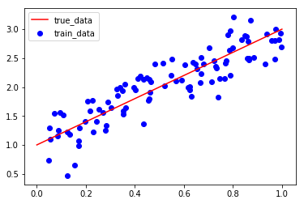

```python
# Specifying data characteristics
num_train = 100
num_test = 20
lim_inf = 0
lim_sup = 1
stdv_noise = 0.3

# True
f_w0 = 1
f_w1 =  2

# Creating training data
X = np.random.rand(num_train, 1)
y = f_w0 + f_w1*X + np.random.normal(scale=stdv_noise, size=X.shape)

# Create true function
X_test = np.linspace(lim_inf, lim_sup, num_test).reshape(-1, 1)
y_true = f_w0 + f_w1*X_test

# Graph
plt.scatter(X, y, color='blue', label='train_data')
plt.plot(X_test, y_true, color='red', label='true_data')
plt.legend()
```

# Posterior Distribution

The posterior distribution was:

$$ p(w/y, \alpha, \beta) = N(w/m_{N}, S_{N}) $$

$$ m_{N} = \beta S_{N}^{-1} \phi^{T}y $$$$ S_{N} =\alpha I + \beta \phi^{T}\phi $$

```python
def posterior(phi, y, alpha, beta):
    """
        Computes the mean and covariance matrix of the posterior distribution by imposing
        an isotropic Gaussian prior with mean vector zero, covariance matrix (alpha^-1)*I
        and a Gaussian likelihood distribution with mean (w^T)*phi and variance beta^-1

        params:
            - phi: design matrix [numpy array of shape (m x k)]
            - y: vector of labels [numpy array of shape (m x 1)]
            - alpha: scalar value representing the precision of the prior
            - beta: scalar value representing the precision of the likelihood

        returns
            - m_N: mean of the posterior.
            -S_N: precision matrix of the posterior
    """
    S_N_inv = alpha*np.eye(phi.shape[1]) + beta*(phi.T.dot(phi))
    S_N = np.linalg.inv(S_N_inv)
    m_N = beta*S_N.dot(phi.T).dot(y)
    return m_N, S_N

# Testing the function
lr = LR()
phi = lr.expand(X, lr.identity_basis_function)
alpha = 2.0
beta = 25.0
m_N, S_N = posterior(phi, y, alpha, beta)
print('We have two weights, therefore the posterior shapes for the mean ' +\
      'vector and precision matrix are: {} and {}'.format(m_N.shape, S_N.shape))
```

```
We have two weights, therefore the posterior shapes for the mean vector and precision matrix are: (2, 1) and (2, 2)
```

# Posterior Predictive Distribution

The posterior predictive was computed as follows:

$$p(y/x, \alpha, \beta)= N(y/u, \frac{1}{\lambda})$$$$u=m_{N}^{T}\phi$$$$\frac{1}{\lambda}=\frac{1}{\beta}+\phi^{T}S_{N}\phi$$

```python
def posterior_predictive(phi, beta, m_N, S_N):
    """
        Computes the mean and variance of the posterior predictive distribution using
        the posterior distribution of the weights that was previously calculated.

        params:
            - phi: design matrix [numpy array of shape (m x k)]
            - m_N: mean of the posterior distribution of the weights
            - S_N: precision matrix of the posterior distribution of the weights
            - beta: scalar value representing the precision of the likelihood

        returns
            - u: mean of the posterior predictive
            -lambda_inv: variance of the posterior predictive
    """
    u = phi.dot(m_N)
    # Only compute variances (diagonal elements of covariance matrix)
    lambda_inv = 1 / beta + np.sum(phi.dot(S_N) * phi, axis=1)
    return u, lambda_inv

# Testing the function
lr = LR()
phi = lr.expand(X, lr.identity_basis_function)
alpha = 2.0
beta = 25.0
m_N, S_N = posterior(phi, y, alpha, beta)
u, lambda_inv = posterior_predictive(phi, beta, m_N, S_N)
print('The mean and variance shapes of the posterior predictive are: {} and {}'.format(u.shape, lambda_inv.shape))
```

```
The mean and variance shapes of the posterior predictive are: (100, 1) and (100,)
```

# Bayesian computation

```python
# Prior variance
alpha = 2.0

# Likelihood variance
beta = 25.0

# Creating design matrix
phi = lr.expand(X, lr.identity_basis_function)
phi_test = lr.expand(X_test, lr.identity_basis_function)

# Mean and covariance matrix of posterior
m_N, S_N = posterior(phi, y, alpha, beta)
print('The posterior distribution of weights have:')
print('   Mean vector: [{} {}]'.format(m_N[0][0], m_N[1][0]))
print('   True weights: [{} {}]'.format(f_w0, f_w1))
print('   Variances: [{} {}]'.format(S_N[0][0], S_N[1][1]))

# Mean and variances of posterior predictive
y_mean, y_var = posterior_predictive(phi_test, beta, m_N, S_N)
y_mean = np.squeeze(y_mean)
```

```
The posterior distribution of weights have:
   Mean vector: [1.0627305709758592 1.8624023969308499]
   True weights: [1 2]
   Variances: [0.0018143957994101565 0.005088116576958816]
```

# Understanding results

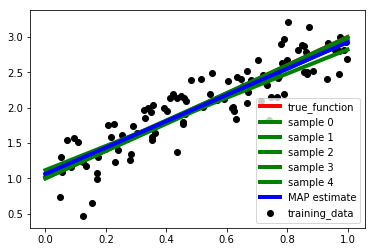

```python
# Get 5 samples of weights
w_samples = np.random.multivariate_normal(m_N.ravel(), S_N, 5).T

# Compute 5 hypotheses for each sample
y_preds = phi_test.dot(w_samples)

# Compute the hypothesis with the MAP estimated weights
w_map = m_N
y_pred_map = phi_test.dot(w_map)

# Plot true function and training data
plt.plot(X_test, y_true, color='r', label='true_function', linewidth=4)
plt.scatter(X, y, color='k', label='training_data')

# Plot 5 hypotheses
for i in range(0, y_preds.shape[1]):
    y_preds[:, i].shape
    plt.plot(X_test, y_preds[:, i], 'g-', linewidth=4, label='sample {}'.format(i))
plt.plot(X_test, y_pred_map, 'b-', label='MAP estimate', linewidth=4)
plt.legend(loc='best')
```

# Plotting posterior distribution

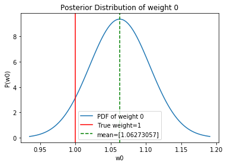

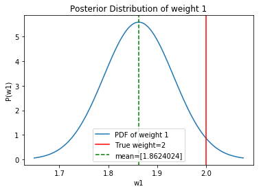

```python
n_samples = 100
true_weights = [f_w0, f_w1]

# Plotting posterior for all weights
for i in range(m_N.shape[0]):
    plt.figure()
    x = np.linspace(m_N[i] - 3*np.sqrt(S_N[i][i]), m_N[i] + 3*np.sqrt(S_N[i][i]), n_samples)
    plt.xlabel('w{}'.format(i))
    plt.ylabel('P(w{})'.format(i))
    plt.plot(x, stats.norm.pdf(x, m_N[i], np.sqrt(S_N[i][i])), label='PDF of weight {}'.format(i))
    plt.title('Posterior Distribution of weight {}'.format(i))
    plt.axvline(x=true_weights[i], color='r', label='True weight={}'.format(true_weights[i]))
    plt.axvline(x=m_N[i], color='g', linestyle='--', label='mean={}'.format(m_N[i]))
    plt.legend(loc='best')
```

# Plotting posterior predictive distribution

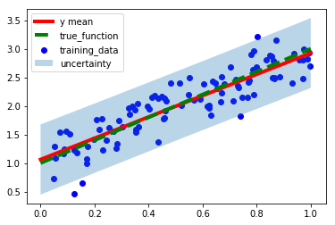

```python
plt.scatter(X, y, color='b', label='training_data')
plt.plot(X_test, y_mean, 'r', linewidth=4, label='y mean')
plt.plot(X_test, y_true, color='g',  linewidth=4, linestyle='--', label='true_function')
plt.fill_between(X_test.ravel(), y_mean + 3*np.sqrt(y_var), y_mean - 3*np.sqrt(y_var), alpha = 0.3, label='uncertainty')
plt.legend(loc='best')
```

# Prepare the data

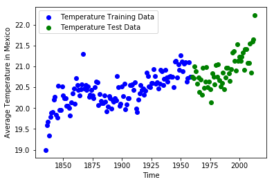

```python
y = np.load('Data/y.npy')
x = np.load('Data/X.npy')

# Split data
split=0.7
x_train = x[0:round(split * x.shape[0])]
y_train = y[0:round(split * y.shape[0])]
x_test = x[round(split * x.shape[0]):]
y_test = y[round(split * y.shape[0]):]

plt.scatter(x_train, y_train, color='b',label='Temperature Training Data')
plt.scatter(x_test, y_test, color='g',label='Temperature Test Data')
plt.xlabel('Time')
plt.ylabel('Average Temperature in Mexico')
plt.legend(loc='best')
```

# Posterior and predictive distributions

```python
# Design Matrix
degree = 2
degrees = range(degree + 1)
phi = lr.expand(x_train, bf=lr.polynomial_basis_function, bf_args=degrees[1:])
phi_test = lr.expand(x_test, bf=lr.polynomial_basis_function, bf_args=degrees[1:])

# Mean and covariance matrix of posterior Polynomial
m_N, S_N = posterior(phi, y_train, alpha, beta)
print('The posterior distribution of weights of the polynomial have the mean vector:')
print(m_N)

# Mean and variances of posterior predictive Polynomial
y_mean, y_var = posterior_predictive(phi_test, beta, m_N, S_N)
y_mean_train, y_var_train = posterior_predictive(phi, beta, m_N, S_N)
y_mean = np.squeeze(y_mean)
y_mean_train = np.squeeze(y_mean_train)
```

```
The posterior distribution of weights of the polynomial have the mean vector:
[[ 9.61926939e-03]
 [ 1.39784327e-02]
 [-1.69774204e-06]]
```

# Plot results

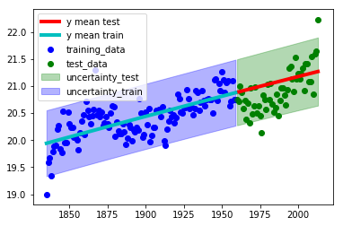

```python
num_sigma = 3

plt.figure()
plt.scatter(x_train, y_train, color='b', label='training_data')
plt.scatter(x_test, y_test, color='g', label='test_data')
plt.plot(x_test, y_mean, 'r', linewidth=4, label='y mean test')
plt.plot(x_train, y_mean_train, 'c', linewidth=4, label='y mean train')
plt.fill_between(x_test.ravel(), y_mean + num_sigma*np.sqrt(y_var), y_mean - num_sigma*np.sqrt(y_var), alpha = 0.3, color='g', label='uncertainty_test')
plt.fill_between(x_train.ravel(), y_mean_train + num_sigma*np.sqrt(y_var_train), y_mean_train - num_sigma*np.sqrt(y_var_train), alpha = 0.3, color='b', label='uncertainty_train')
plt.legend(loc='best')
```